# Basic Stats

Robert W Schlegel

2018-01-29

# Basic statistics

In this quick tutorial we are going to look at how to perform some basic statistical tests. Before we do so, let’s remind ourselves how to test the two most common assumptions we must make for any comparison of means test. These are kurtosis and homoscedasticity. Or rather in common parlance, normality of distribution and equality of variance.

We will use the `laminaria` and `SACTN` data for our examples below in order to practice running the numbers.

```r
# Load libraries
library(tidyverse)
library(ggpmisc)
library(pgirmess)

# Load data
laminaria <- read_csv("../data/laminaria.csv")
SACTN <- read_csv("../data/SACTN_data.csv")
```

With the libraries and data loaded, we will also create a couple of smaller dataframes from the Laminaria data to make it easier to perform our t-tests.

```r
# Be careful here as we are overwriting our raw data
lam_1 <- laminaria %>%
  select(region, site, total_length)

# Create dataframe with a couple of morphometric properties
lam_2 <- laminaria %>%
  select(region, site, digits, blade_length)
```

## Testing assumptions

To test the normality of the distribution of a set of data we may use the `shapiro.test()` function. This produces a ‘w’ score as well as a *p*-value, but for now we are only interested in the later. Anything above *p* = 0.05 may considered to be normally distributed.

To test for similarity of variance we will run the `var()` function. As long as no group of data has ~4 times greater variance than any other group we are comparing it against it will pass this test.

With the help of the `%>%` we may test all of our assumptions in one pass.

```r
# First test the Laminaria data by region
  # This passes our tests
lam_norm_region <- laminaria %>%
  group_by(region) %>%
  summarise(norm_length = shapiro.test(total_length)[2],
            var_length = var(total_length)) %>%
  ungroup()

# Then test by site
  # This no longer passes our tests
lam_norm_site <- laminaria %>%
  group_by(site) %>%
  summarise(norm_length = shapiro.test(total_length)[2],
            var_length = var(total_length)) %>%
  ungroup()

# Lastly we test the SACTN data
  # Which also fails
SACTN_norm <- SACTN %>%
  group_by(index) %>%
  summarise(norm_temp = shapiro.test(temp)[2],
            var_temp = var(temp, na.rm = T))
```

## Comparison of two means

To run a t-test we use `t.test()`. The argument this function wants is in the form of a formula. This requires to bits of information separated by a `~`. On the left we provide the name of the column containing the variable we want to compare between two groups. On the right we put the column containing the grouping variable. The second argument we provide is `data = x`, where we tell R what the name of the dataframe is that contains the columns we have fed to the formula.

```r
t.test(total_length ~ region, data = laminaria)
```

```
R>
R>  Welch Two Sample t-test
R>
R> data:  total_length by region
R> t = -7.2802, df = 65.266, p-value = 5.426e-10
R> alternative hypothesis: true difference in means is not equal to 0
R> 95 percent confidence interval:
R>  -84.76027 -48.26973
R> sample estimates:
R> mean in group FB mean in group WC
R>          230.810          297.325
```

Happily the Laminaria data, when separated by region, pass our assumption tests. Had they not, we would need to use a Wilcox test instead of a t-test. Note that the arguments are written the exact same for both functions.

```r
wilcox.test(total_length ~ region, data = laminaria)
```

```
R>
R>  Wilcoxon rank sum test with continuity correction
R>
R> data:  total_length by region
R> W = 629.5, p-value = 2.62e-10
R> alternative hypothesis: true location shift is not equal to 0
```

## Comparison of multiple means

The function we use to compare multiple means that pass our assumption tests (parametric data) are `aov()` for an ANOVA and for non-parametric data we use `kruskal.test()` for a Kruskal-Wallis test. To see the difference between the individual factor levels within our multiple means comparisons tests we use `TukeyHSD()` for parametric data and `kruskalmc()` for non-parametric data. Note that `aov()` does not by defalut output the information we are after so we wrap it inside of `summary()`. Note that the Laminaria and SACTN data violate our assumptions. We should therefore not perform paramteric tests on them. We do so below to highlight how these tests work should one have parametric data to use.

```r
# Look at the significance results for Laminaria total lengths
summary(aov(total_length ~ site, data = laminaria))
```

```
R>              Df Sum Sq Mean Sq F value Pr(>F)
R> site         12 254779   21232   15.83 <2e-16 ***
R> Residuals   127 170362    1341
R> ---
R> Signif. codes:  0 '***' 0.001 '**' 0.01 '*' 0.05 '.' 0.1 ' ' 1
```

```r
# Look at the Tukey test results
TukeyHSD(aov(total_length ~ site, data = laminaria))
```

```
R>   Tukey multiple comparisons of means
R>     95% family-wise confidence level
R>
R> Fit: aov(formula = total_length ~ site, data = laminaria)
R>
R> $site
R>                                          diff          lwr        upr
R> Baboon Rock-A-Frame                 5.1666667  -45.3254139  55.658747
R> Batsata Rock-A-Frame               51.1333333   -1.8232075 104.089874
R> Betty's Bay-A-Frame                98.7500000   48.2579195 149.242081
R> Bordjiestif North-A-Frame          52.6333333   -0.3232075 105.589874
R> Buffels-A-Frame                    71.3333333   20.8412528 121.825414
R> Buffels South-A-Frame              43.0000000   -7.4920805  93.492081
R> Kommetjie-A-Frame                  81.0000000   26.4623198 135.537680
R> Miller's Point-A-Frame             24.4444444  -30.0932358  78.982125
R> Olifantsbos-A-Frame               114.5333333   61.5767925 167.489874
R> Rocky Bank-A-Frame                148.3333333   96.7064576 199.960209
R> Roman Rock-A-Frame                 21.6060606  -30.0208151  73.232936
R> Sea Point-A-Frame                  80.0333333   27.0767925 132.989874
R> Batsata Rock-Baboon Rock           45.9666667   -6.9898741  98.923207
R> Betty's Bay-Baboon Rock            93.5833333   43.0912528 144.075414
R> Bordjiestif North-Baboon Rock      47.4666667   -5.4898741 100.423207
R> Buffels-Baboon Rock                66.1666667   15.6745861 116.658747
R> Buffels South-Baboon Rock          37.8333333  -12.6587472  88.325414
R> Kommetjie-Baboon Rock              75.8333333   21.2956531 130.371014
R> Miller's Point-Baboon Rock         19.2777778  -35.2599024  73.815458
R> Olifantsbos-Baboon Rock           109.3666667   56.4101259 162.323207
R> Rocky Bank-Baboon Rock            143.1666667   91.5397910 194.793542
R> Roman Rock-Baboon Rock             16.4393939  -35.1874818  68.066270
R> Sea Point-Baboon Rock              74.8666667   21.9101259 127.823207
R> Betty's Bay-Batsata Rock           47.6166667   -5.3398741 100.573207
R> Bordjiestif North-Batsata Rock      1.5000000  -53.8113030  56.811303
R> Buffels-Batsata Rock               20.2000000  -32.7565408  73.156541
R> Buffels South-Batsata Rock         -8.1333333  -61.0898741  44.823207
R> Kommetjie-Batsata Rock             29.8666667  -26.9602951  86.693628
R> Miller's Point-Batsata Rock       -26.6888889  -83.5158506  30.138073
R> Olifantsbos-Batsata Rock           63.4000000    8.0886970 118.711303
R> Rocky Bank-Batsata Rock            97.2000000   43.1603912 151.239609
R> Roman Rock-Batsata Rock           -29.5272727  -83.5668815  24.512336
R> Sea Point-Batsata Rock             28.9000000  -26.4113030  84.211303
```

[output cut: 109 more lines]

```
R> Miller's Point-Kommetjie         0.0665882
R> Olifantsbos-Kommetjie            0.7356147
R> Rocky Bank-Kommetjie             0.0048931
R> Roman Rock-Kommetjie             0.0249034
R> Sea Point-Kommetjie              1.0000000
R> Olifantsbos-Miller's Point       0.0000291
R> Rocky Bank-Miller's Point        0.0000000
R> Roman Rock-Miller's Point        1.0000000
R> Sea Point-Miller's Point         0.0616483
R> Rocky Bank-Olifantsbos           0.6553080
R> Roman Rock-Olifantsbos           0.0000037
R> Sea Point-Olifantsbos            0.6593630
R> Roman Rock-Rocky Bank            0.0000000
R> Sea Point-Rocky Bank             0.0025496
R> Sea Point-Roman Rock             0.0217304
```

```r
# Multi-level ANOVA
  # Interaction between factorial levels
summary(aov(total_length ~ region * site, data = laminaria))
```

```
R>              Df Sum Sq Mean Sq F value   Pr(>F)
R> region        1 126407  126407   94.23  < 2e-16 ***
R> site         11 128372   11670    8.70 2.39e-11 ***
R> Residuals   127 170362    1341
R> ---
R> Signif. codes:  0 '***' 0.001 '**' 0.01 '*' 0.05 '.' 0.1 ' ' 1
```

```r
TukeyHSD(aov(total_length ~ region * site, data = laminaria))
```

```
R>   Tukey multiple comparisons of means
R>     95% family-wise confidence level
R>
R> Fit: aov(formula = total_length ~ region * site, data = laminaria)
R>
R> $region
R>         diff      lwr      upr p adj
R> WC-FB 66.515 52.95608 80.07392     0
R>
R> $site
R>                                         diff          lwr        upr
R> Baboon Rock-A-Frame                5.1666667  -45.3254139  55.658747
R> Batsata Rock-A-Frame              51.1333333   -1.8232075 104.089874
R> Betty's Bay-A-Frame               98.7500000   48.2579195 149.242081
R> Bordjiestif North-A-Frame         52.6333333   -0.3232075 105.589874
R> Buffels-A-Frame                   71.3333333   20.8412528 121.825414
R> Buffels South-A-Frame             43.0000000   -7.4920805  93.492081
R> Kommetjie-A-Frame                 14.4850000  -40.0526802  69.022680
R> Miller's Point-A-Frame            24.4444444  -30.0932358  78.982125
R> Olifantsbos-A-Frame               48.0183333   -4.9382075 100.974874
R> Rocky Bank-A-Frame                81.8183333   30.1914576 133.445209
R> Roman Rock-A-Frame                21.6060606  -30.0208151  73.232936
R> Sea Point-A-Frame                 13.5183333  -39.4382075  66.474874
R> Batsata Rock-Baboon Rock          45.9666667   -6.9898741  98.923207
R> Betty's Bay-Baboon Rock           93.5833333   43.0912528 144.075414
R> Bordjiestif North-Baboon Rock     47.4666667   -5.4898741 100.423207
R> Buffels-Baboon Rock               66.1666667   15.6745861 116.658747
R> Buffels South-Baboon Rock         37.8333333  -12.6587472  88.325414
R> Kommetjie-Baboon Rock              9.3183333  -45.2193469  63.856014
R> Miller's Point-Baboon Rock        19.2777778  -35.2599024  73.815458
R> Olifantsbos-Baboon Rock           42.8516667  -10.1048741  95.808207
R> Rocky Bank-Baboon Rock            76.6516667   25.0247910 128.278542
R> Roman Rock-Baboon Rock            16.4393939  -35.1874818  68.066270
R> Sea Point-Baboon Rock              8.3516667  -44.6048741  61.308207
R> Betty's Bay-Batsata Rock          47.6166667   -5.3398741 100.573207
R> Bordjiestif North-Batsata Rock     1.5000000  -53.8113030  56.811303
R> Buffels-Batsata Rock              20.2000000  -32.7565408  73.156541
R> Buffels South-Batsata Rock        -8.1333333  -61.0898741  44.823207
R> Kommetjie-Batsata Rock           -36.6483333  -93.4752951  20.178628
R> Miller's Point-Batsata Rock      -26.6888889  -83.5158506  30.138073
```

[output cut: 113 more lines]

```
R> Miller's Point-Kommetjie         0.9999958
R> Olifantsbos-Kommetjie            0.7356147
R> Rocky Bank-Kommetjie             0.0048931
R> Roman Rock-Kommetjie             0.9999998
R> Sea Point-Kommetjie              1.0000000
R> Olifantsbos-Miller's Point       0.9723715
R> Rocky Bank-Miller's Point        0.0363201
R> Roman Rock-Miller's Point        1.0000000
R> Sea Point-Miller's Point         0.9999843
R> Rocky Bank-Olifantsbos           0.6553080
R> Roman Rock-Olifantsbos           0.9099466
R> Sea Point-Olifantsbos            0.6593630
R> Roman Rock-Rocky Bank            0.0111008
R> Sea Point-Rocky Bank             0.0025496
R> Sea Point-Roman Rock             0.9999990
```

```r
# Single level non-parametric test
kruskal.test(total_length ~ as.factor(site), data = laminaria)
```

```
R>
R>  Kruskal-Wallis rank sum test
R>
R> data:  total_length by as.factor(site)
R> Kruskal-Wallis chi-squared = 84.788, df = 12, p-value = 5e-13
```

```r
# Post-test
kruskalmc(total_length ~ as.factor(site), data = laminaria)
```

```
R> Multiple comparison test after Kruskal-Wallis
R> p.value: 0.05
R> Comparisons
R>                                     obs.dif critical.dif difference
R> A-Frame-Baboon Rock                7.125000     56.52288      FALSE
R> A-Frame-Batsata Rock              43.341667     59.28170      FALSE
R> A-Frame-Betty's Bay               77.208333     56.52288       TRUE
R> A-Frame-Bordjiestif North         45.091667     59.28170      FALSE
R> A-Frame-Buffels                   62.666667     56.52288       TRUE
R> A-Frame-Buffels South             34.708333     56.52288      FALSE
R> A-Frame-Kommetjie                 65.347222     61.05169       TRUE
R> A-Frame-Miller's Point            19.513889     61.05169      FALSE
R> A-Frame-Olifantsbos               85.541667     59.28170       TRUE
R> A-Frame-Rocky Bank               105.928030     57.79322       TRUE
R> A-Frame-Roman Rock                15.291667     57.79322      FALSE
R> A-Frame-Sea Point                 67.341667     59.28170       TRUE
R> Baboon Rock-Batsata Rock          36.216667     59.28170      FALSE
R> Baboon Rock-Betty's Bay           70.083333     56.52288       TRUE
R> Baboon Rock-Bordjiestif North     37.966667     59.28170      FALSE
R> Baboon Rock-Buffels               55.541667     56.52288      FALSE
R> Baboon Rock-Buffels South         27.583333     56.52288      FALSE
R> Baboon Rock-Kommetjie             58.222222     61.05169      FALSE
R> Baboon Rock-Miller's Point        12.388889     61.05169      FALSE
R> Baboon Rock-Olifantsbos           78.416667     59.28170       TRUE
R> Baboon Rock-Rocky Bank            98.803030     57.79322       TRUE
R> Baboon Rock-Roman Rock             8.166667     57.79322      FALSE
R> Baboon Rock-Sea Point             60.216667     59.28170       TRUE
R> Batsata Rock-Betty's Bay          33.866667     59.28170      FALSE
R> Batsata Rock-Bordjiestif North     1.750000     61.91772      FALSE
R> Batsata Rock-Buffels              19.325000     59.28170      FALSE
R> Batsata Rock-Buffels South         8.633333     59.28170      FALSE
R> Batsata Rock-Kommetjie            22.005556     63.61441      FALSE
R> Batsata Rock-Miller's Point       23.827778     63.61441      FALSE
R> Batsata Rock-Olifantsbos          42.200000     61.91772      FALSE
R> Batsata Rock-Rocky Bank           62.586364     60.49413       TRUE
R> Batsata Rock-Roman Rock           28.050000     60.49413      FALSE
R> Batsata Rock-Sea Point            24.000000     61.91772      FALSE
R> Betty's Bay-Bordjiestif North     32.116667     59.28170      FALSE
R> Betty's Bay-Buffels               14.541667     56.52288      FALSE
R> Betty's Bay-Buffels South         42.500000     56.52288      FALSE
```

[output cut: 27 more lines]

```
R> Kommetjie-Miller's Point          45.833333     65.26700      FALSE
R> Kommetjie-Olifantsbos             20.194444     63.61441      FALSE
R> Kommetjie-Rocky Bank              40.580808     62.22965      FALSE
R> Kommetjie-Roman Rock              50.055556     62.22965      FALSE
R> Kommetjie-Sea Point                1.994444     63.61441      FALSE
R> Miller's Point-Olifantsbos        66.027778     63.61441       TRUE
R> Miller's Point-Rocky Bank         86.414141     62.22965       TRUE
R> Miller's Point-Roman Rock          4.222222     62.22965      FALSE
R> Miller's Point-Sea Point          47.827778     63.61441      FALSE
R> Olifantsbos-Rocky Bank            20.386364     60.49413      FALSE
R> Olifantsbos-Roman Rock            70.250000     60.49413       TRUE
R> Olifantsbos-Sea Point             18.200000     61.91772      FALSE
R> Rocky Bank-Roman Rock             90.636364     59.03623       TRUE
R> Rocky Bank-Sea Point              38.586364     60.49413      FALSE
R> Roman Rock-Sea Point              52.050000     60.49413      FALSE
```

## Correlation

To check for the correlation between multiple values we may use `cor()`. This may be done in the pipe very quickly, but we have also provided below how to perfomr this test using the base R syntax.

```r
# Using the pipe
  # This allows us to compare multple columns of our choosing easily
laminaria %>%
  select(-(region:Ind)) %>%
  cor(., use = "complete.obs")
```

```
R>                 blade_weight blade_length blade_thickness   stipe_mass
R> blade_weight      1.00000000  0.425185083      0.03219957  0.426179252
R> blade_length      0.42518508  1.000000000     -0.30557540  0.442698979
R> blade_thickness   0.03219957 -0.305575396      1.00000000 -0.375644234
R> stipe_mass        0.42617925  0.442698979     -0.37564423  1.000000000
R> stipe_length      0.32759260  0.357362105     -0.37118521  0.880552448
R> stipe_diameter    0.33222608  0.149953171     -0.22077150  0.558113994
R> digits            0.44968877 -0.008451233      0.09725484 -0.008640478
R> thallus_mass      0.73877911  0.509337100     -0.18622771  0.818623801
R> total_length      0.47297117  0.701734473     -0.37723423  0.834488665
R>                 stipe_length stipe_diameter       digits thallus_mass
R> blade_weight      0.32759260      0.3322261  0.449688765    0.7387791
R> blade_length      0.35736211      0.1499532 -0.008451233    0.5093371
R> blade_thickness  -0.37118521     -0.2207715  0.097254839   -0.1862277
R> stipe_mass        0.88055245      0.5581140 -0.008640478    0.8186238
R> stipe_length      1.00000000      0.6001000 -0.015358110    0.6863730
R> stipe_diameter    0.60010004      1.0000000  0.269379525    0.4743357
R> digits           -0.01535811      0.2693795  1.000000000    0.2136535
R> thallus_mass      0.68637303      0.4743357  0.213653547    1.0000000
R> total_length      0.87806926      0.5042686 -0.036630567    0.7654441
R>                 total_length
R> blade_weight      0.47297117
R> blade_length      0.70173447
R> blade_thickness  -0.37723423
R> stipe_mass        0.83448866
R> stipe_length      0.87806926
R> stipe_diameter    0.50426865
R> digits           -0.03663057
R> thallus_mass      0.76544406
R> total_length      1.00000000
```

```r
# Or base R syntax
  # Here we must specify individual columns
cor(laminaria$digits, laminaria$blade_length)
```

```
R> [1] -0.01933535
```

## Regression analysis

```r
# The summary
summary(lm(stipe_diameter ~ stipe_mass, data = laminaria))
```

```
R>
R> Call:
R> lm(formula = stipe_diameter ~ stipe_mass, data = laminaria)
R>
R> Residuals:
R>     Min      1Q  Median      3Q     Max
R> -33.576   0.016   5.503   8.570  32.107
R>
R> Coefficients:
R>             Estimate Std. Error t value Pr(>|t|)
R> (Intercept)   25.364      2.141  11.846  < 2e-16 ***
R> stipe_mass    10.025      1.278   7.844 1.14e-12 ***
R> ---
R> Signif. codes:  0 '***' 0.001 '**' 0.01 '*' 0.05 '.' 0.1 ' ' 1
R>
R> Residual standard error: 14.87 on 136 degrees of freedom
R>   (2 observations deleted due to missingness)
R> Multiple R-squared:  0.3115, Adjusted R-squared:  0.3064
R> F-statistic: 61.53 on 1 and 136 DF,  p-value: 1.145e-12
```

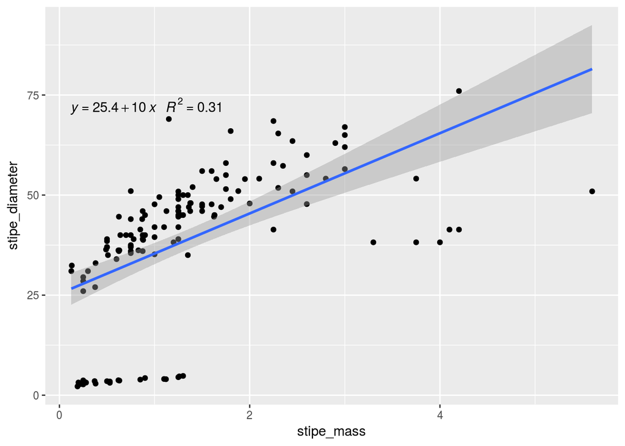

```r
# Plot the R2 value
ggplot(data = laminaria, aes(x = stipe_mass, y = stipe_diameter)) +
  geom_point() +
  geom_smooth(method = "lm") +
  stat_poly_eq(formula = y ~ x,
                aes(label = paste(..eq.label.., ..rr.label.., sep = "~~~")),
                parse = TRUE)
```